# R Notebook

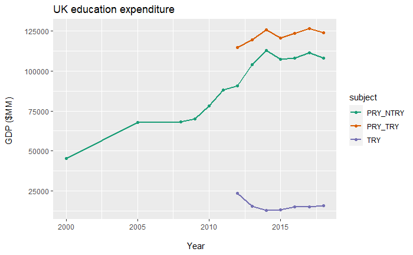

```r
edu_exp_usd %>%
  select(-c(indicator, frequency, measure, flag_codes)) %>%
  filter(location %in% c("GBR")) %>%
  ggplot() +
  aes(x = time, y = value_mil_usd, colour = subject) +
  geom_line(size = 0.75) +
  geom_point(size = 1.5) +
  scale_colour_brewer(palette = "Dark2") +
  # scale_colour_manual(values = cbb_palette) +
  ggtitle("UK education expenditure") +
  labs(
    x = "\n Year",
    y = "GDP ($MM) \n"
  )
```

G-7 expenditure on education

```r
edu_exp_g7 <- edu_exp %>%
  filter(
    location %in% c("CAN", "FRA", "DEU", "ITA", "JPN", "USA", "GBR")
    ) %>%
  select(-c(indicator, frequency, measure, flag_codes)) %>%
  pivot_wider(names_from = subject, values_from = value) %>%
  rename(
    try_pc_gdp = TRY,
    pry_ntry_pc_gdp = PRY_NTRY,
    pry_try_pc_gdp = PRY_TRY
  ) %>%
  left_join(gdp_light, by = c("location", "time"))%>%
  mutate(
    try_mil_usd = try_pc_gdp * gdp / 100,
    pry_ntry_mil_usd = pry_ntry_pc_gdp * gdp / 100,
    pry_try_mil_usd = pry_try_pc_gdp * gdp / 100
  ) %>%
  select(-try_pc_gdp, -pry_ntry_pc_gdp, -pry_try_pc_gdp, -gdp)%>%
  arrange(location, time)
```

**Data for modelling**

```r
productivity <- gdp_phw_g7 %>%
  left_join(edu_exp_g7, by = c("location", "time")) %>%
  left_join(inv_asset_g7, by = c("location", "time"))

glimpse(productivity)
```

```
Rows: 360
Columns: 12
$ location           <chr> "CAN", "CAN", "CAN", "CAN", "CAN", "CAN", "CAN", "CAN", "CAN", "CAN", "CAN", "CAN", "CAN", "CAN",~
$ time               <dttm> 1970-01-01, 1971-01-01, 1972-01-01, 1973-01-01, 1974-01-01, 1975-01-01, 1976-01-01, 1977-01-01, ~
$ gdp_phw_usd        <dbl> 28.62992, 29.33436, 30.35025, 31.07351, 31.07195, 31.42778, 33.28053, 34.20403, 34.45608, 34.1169~
$ try_mil_usd        <dbl> NA, NA, NA, NA, NA, NA, NA, NA, NA, NA, NA, NA, NA, NA, NA, NA, NA, NA, NA, NA, NA, NA, NA, NA, N~
$ pry_ntry_mil_usd   <dbl> NA, NA, NA, NA, NA, NA, NA, NA, NA, NA, NA, NA, NA, NA, NA, NA, NA, NA, NA, NA, NA, NA, NA, NA, N~
$ pry_try_mil_usd    <dbl> NA, NA, NA, NA, NA, NA, NA, NA, NA, NA, NA, NA, NA, NA, NA, NA, NA, NA, NA, NA, NA, NA, NA, NA, N~
$ ict_mil_usd        <dbl> NA, NA, NA, NA, NA, NA, 2642.131, 2758.330, 3050.458, 3438.862, 4150.366, 5697.235, 5616.704, 606~
$ cultasset_mil_usd  <dbl> NA, NA, NA, NA, NA, NA, NA, NA, NA, NA, NA, NA, NA, NA, NA, NA, NA, NA, NA, NA, NA, NA, NA, NA, N~
$ infrastuct_mil_usd <dbl> 8870.039, 10039.748, 10300.079, 11278.354, 13374.034, 16161.353, 15926.709, 17483.943, 18867.548,~
$ intelprop_mil_usd  <dbl> 1365.360, 1517.127, 1578.875, 1637.687, 1769.458, 2034.349, 2609.275, 2999.763, 3437.905, 3984.10~
$ transpeqt_mil_usd  <dbl> NA, NA, NA, NA, NA, NA, NA, NA, NA, NA, NA, 4158.514, 3149.827, 3769.343, 4845.802, 5469.769, 565~
$ dwelling_mil_usd   <dbl> 4982.125, 6168.938, 7262.403, 8810.676, 9991.444, 10457.235, 13265.412, 13919.626, 14895.768, 157~
```

Trim UK data

```r
prod_uk_trim <- productivity %>%
  mutate(time = year(time)) %>%
  filter(
    location == "GBR",
    time >= 1995 & time <=2019
  ) %>%
  select(
    gdp_phw_usd,
    ict_mil_usd,
    cultasset_mil_usd,
    infrastuct_mil_usd,
    intelprop_mil_usd,
    transpeqt_mil_usd,
    dwelling_mil_usd
  ) %>%
  mutate(
    ict_bil_usd = ict_mil_usd / 1000,
    cultasset_bil_usd = cultasset_mil_usd / 1000,
    infrastuct_bil_usd = infrastuct_mil_usd / 1000,
    intelprop_bil_usd = intelprop_mil_usd / 1000,
    transpeqt_bil_usd = transpeqt_mil_usd / 1000,
    dwelling_bil_usd = dwelling_mil_usd / 1000
  ) %>%
  select(
    -ict_mil_usd,
    -cultasset_mil_usd,
    -infrastuct_mil_usd,
    -intelprop_mil_usd,
    -transpeqt_mil_usd,
    -dwelling_mil_usd
  )
```

Check for aliases

```r
alias(lm(gdp_phw_usd ~ ., data = prod_uk_trim))
```

```
Model :
gdp_phw_usd ~ ict_bil_usd + cultasset_bil_usd + infrastuct_bil_usd +
    intelprop_bil_usd + transpeqt_bil_usd + dwelling_bil_usd
```

Call libraries for linear regression modelling

```r
library(GGally)
library(ggfortify)
library(modelr)
```

Check for correlations in data

[output not shown]

[output cut: 17 more lines]

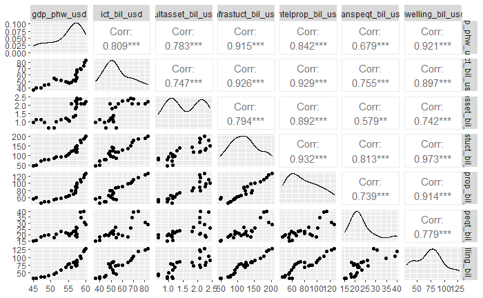

```r
ggpairs(prod_uk_trim)
```

Simple linear regression

Response: gdp_phw_usd

Predictors (tentative): - dwelling - infrastruct - intelprop_bil_usd

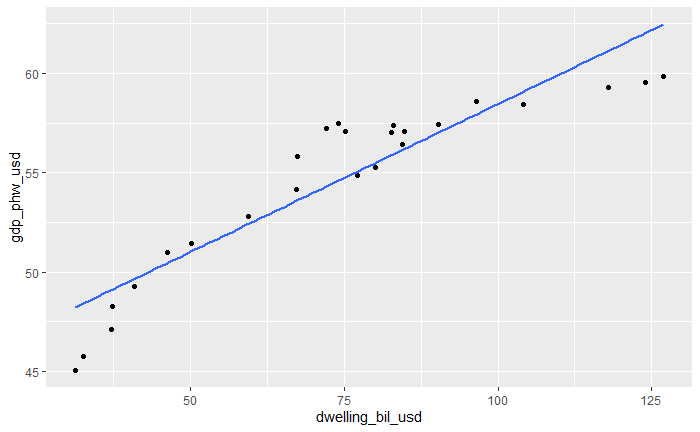

```r
prod_uk_trim %>%
  ggplot(aes(x = dwelling_bil_usd, y = gdp_phw_usd)) +
  geom_point() +
  geom_smooth(method = "lm", se = FALSE)
```

Goodness-of-fit diagnostics

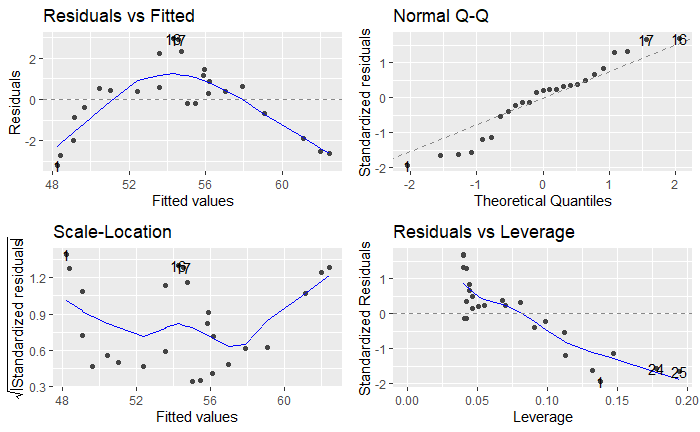

```r
model_1 <- lm(gdp_phw_usd ~ dwelling_bil_usd, data = prod_uk_trim)

autoplot(model_1) #diagnostics
```

```r
summary(model_1)
```

```
Call:
lm(formula = gdp_phw_usd ~ dwelling_bil_usd, data = prod_uk_trim)

Residuals:
    Min      1Q  Median      3Q     Max
-3.1696 -0.8730  0.3704  0.8748  2.9304

Coefficients:
                 Estimate Std. Error t value Pr(>|t|)
(Intercept)      43.57210    1.02744   42.41  < 2e-16 ***
dwelling_bil_usd  0.14883    0.01308   11.38 6.38e-11 ***
---
Signif. codes:  0 ‘***’ 0.001 ‘**’ 0.01 ‘*’ 0.05 ‘.’ 0.1 ‘ ’ 1

Residual standard error: 1.772 on 23 degrees of freedom
Multiple R-squared:  0.8491,    Adjusted R-squared:  0.8425
F-statistic: 129.4 on 1 and 23 DF,  p-value: 6.381e-11
```

Check of second candidate predictor Goodness-of-fit diagnostics

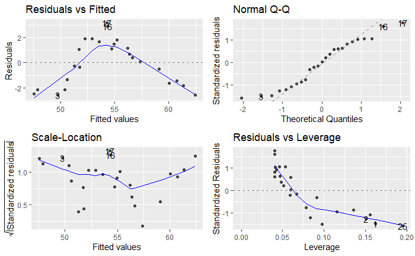

```r
model_1b <- lm(gdp_phw_usd ~ infrastuct_bil_usd, data = prod_uk_trim)

autoplot(model_1b) #diagnostics
```

```r
summary(model_1b)
```

```
Call:
lm(formula = gdp_phw_usd ~ infrastuct_bil_usd, data = prod_uk_trim)

Residuals:
    Min      1Q  Median      3Q     Max
-2.6010 -1.6375  0.0552  1.4969  3.1740

Coefficients:
                    Estimate Std. Error t value Pr(>|t|)
(Intercept)        43.004370   1.119384   38.42  < 2e-16 ***
infrastuct_bil_usd  0.095644   0.008766   10.91 1.44e-10 ***
---
Signif. codes:  0 ‘***’ 0.001 ‘**’ 0.01 ‘*’ 0.05 ‘.’ 0.1 ‘ ’ 1

Residual standard error: 1.836 on 23 degrees of freedom
Multiple R-squared:  0.8381,    Adjusted R-squared:  0.831
F-statistic:   119 on 1 and 23 DF,  p-value: 1.442e-10
```

Check of third candidate predictor Goodness-of-fit diagnostics

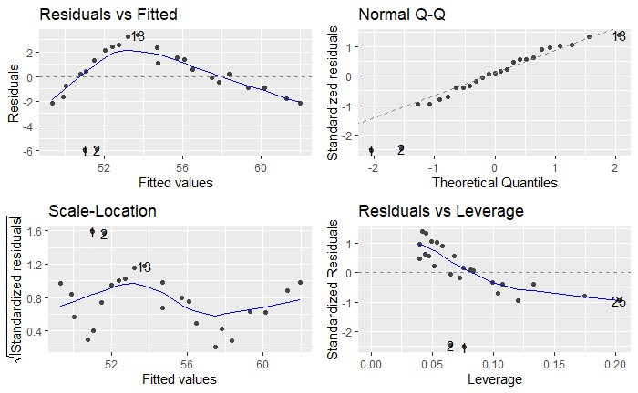

```r
model_1c <- lm(gdp_phw_usd ~ intelprop_bil_usd, data = prod_uk_trim)

autoplot(model_1c) #diagnostics
```

```r
summary(model_1c)
```

```
Call:
lm(formula = gdp_phw_usd ~ intelprop_bil_usd, data = prod_uk_trim)

Residuals:
    Min      1Q  Median      3Q     Max
-5.9624 -0.9199  0.2055  1.5255  3.3375

Coefficients:
                  Estimate Std. Error t value Pr(>|t|)
(Intercept)       42.57608    1.67579  25.407  < 2e-16 ***
intelprop_bil_usd  0.15221    0.02037   7.471 1.36e-07 ***
---
Signif. codes:  0 ‘***’ 0.001 ‘**’ 0.01 ‘*’ 0.05 ‘.’ 0.1 ‘ ’ 1

Residual standard error: 2.464 on 23 degrees of freedom
Multiple R-squared:  0.7082,    Adjusted R-squared:  0.6955
F-statistic: 55.81 on 1 and 23 DF,  p-value: 1.36e-07
```

Based on the above results we can stick to `dwelling_bil_usd` and model_1

- Adding a second predictor to the model

Calculate residuals

[output not shown]

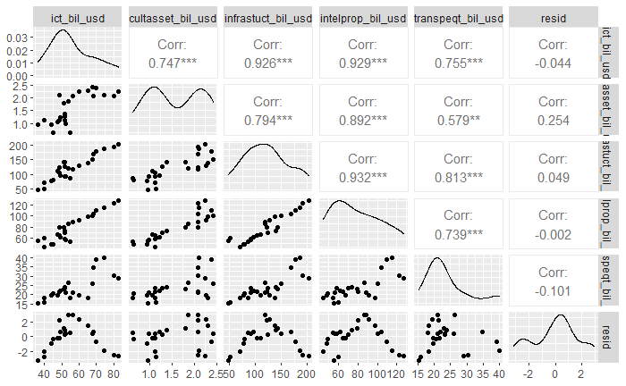

```r
prod_uk_remaining_resid <- prod_uk_trim %>%
  add_residuals(model_1) %>%
  select(-c(gdp_phw_usd, dwelling_bil_usd))


prod_uk_remaining_resid %>%
  ggpairs()
```

It seems that `cultasset_bil_usd` is a good candidate for a second predictor followed by `infrastuct_bil_usd` and `ict_bil_usd`

Model with `cultasset_bil_usd` (model_2a)

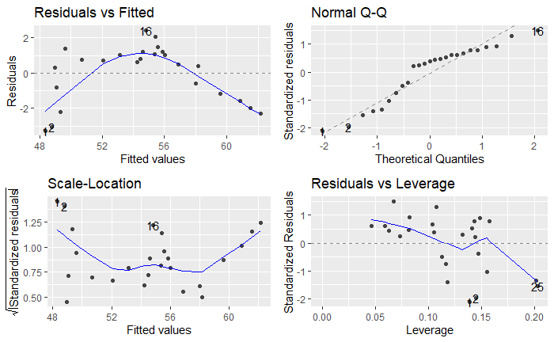

```r
model_2a <- lm(gdp_phw_usd ~ dwelling_bil_usd + cultasset_bil_usd, data = prod_uk_trim)

autoplot(model_2a) #diagnostics
```

```r
summary(model_2a)
```

```
Call:
lm(formula = gdp_phw_usd ~ dwelling_bil_usd + cultasset_bil_usd,
    data = prod_uk_trim)

Residuals:
    Min      1Q  Median      3Q     Max
-3.2723 -1.1873  0.6114  1.0606  2.3977

Coefficients:
                  Estimate Std. Error t value Pr(>|t|)
(Intercept)       42.90082    1.03328  41.519  < 2e-16 ***
dwelling_bil_usd   0.12250    0.01848   6.630 1.15e-06 ***
cultasset_bil_usd  1.65700    0.86334   1.919    0.068 .
---
Signif. codes:  0 ‘***’ 0.001 ‘**’ 0.01 ‘*’ 0.05 ‘.’ 0.1 ‘ ’ 1

Residual standard error: 1.677 on 22 degrees of freedom
Multiple R-squared:  0.8707,    Adjusted R-squared:  0.859
F-statistic: 74.08 on 2 and 22 DF,  p-value: 1.687e-10
```

The `cultasset_bil_usd` regression coefficient is not statistically significant

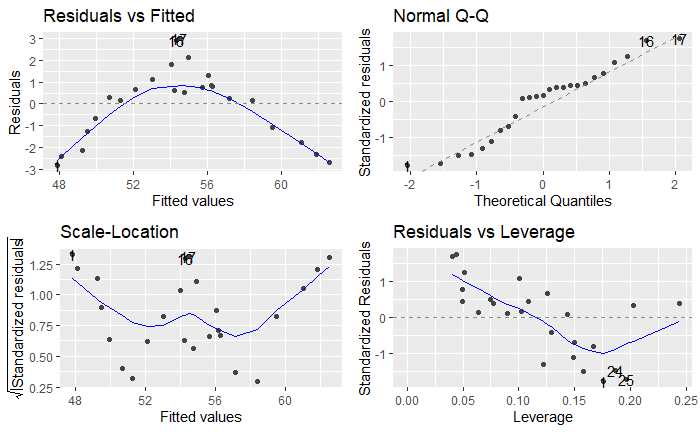

```r
model_2b <- lm(gdp_phw_usd ~ dwelling_bil_usd + infrastuct_bil_usd, data = prod_uk_trim)

autoplot(model_2b) #diagnostics
```

```r
summary(model_2b)
```

```
Call:
lm(formula = gdp_phw_usd ~ dwelling_bil_usd + infrastuct_bil_usd,
    data = prod_uk_trim)

Residuals:
    Min      1Q  Median      3Q     Max
-2.8200 -1.2925  0.2738  0.8605  2.9944

Coefficients:
                   Estimate Std. Error t value Pr(>|t|)
(Intercept)        43.20926    1.08710  39.747   <2e-16 ***
dwelling_bil_usd    0.09300    0.05649   1.646    0.114
infrastuct_bil_usd  0.03712    0.03654   1.016    0.321
---
Signif. codes:  0 ‘***’ 0.001 ‘**’ 0.01 ‘*’ 0.05 ‘.’ 0.1 ‘ ’ 1

Residual standard error: 1.771 on 22 degrees of freedom
Multiple R-squared:  0.8558,    Adjusted R-squared:  0.8427
F-statistic:  65.3 on 2 and 22 DF,  p-value: 5.594e-10
```

Including regressor `infrastuct_bil_usd` is not improving at all the predictive power of the model and the regression coeffs are not looking good.

Model with `ict_bil_usd` (model_2c)

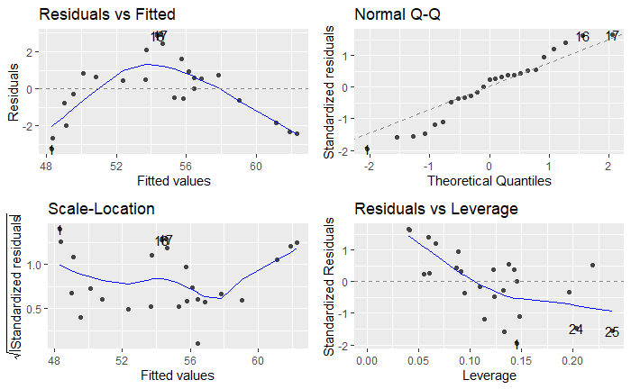

```r
model_2c <- lm(gdp_phw_usd ~ dwelling_bil_usd + ict_bil_usd, data = prod_uk_trim)

autoplot(model_2c) #diagnostics
```

```r
summary(model_2c)
```

```
Call:
lm(formula = gdp_phw_usd ~ dwelling_bil_usd + ict_bil_usd, data = prod_uk_trim)

Residuals:
    Min      1Q  Median      3Q     Max
-3.2432 -0.7834  0.4276  0.8495  2.9052

Coefficients:
                 Estimate Std. Error t value Pr(>|t|)
(Intercept)      44.39044    2.03473  21.816  < 2e-16 ***
dwelling_bil_usd  0.16147    0.03007   5.369 2.16e-05 ***
ict_bil_usd      -0.03146    0.06710  -0.469    0.644
---
Signif. codes:  0 ‘***’ 0.001 ‘**’ 0.01 ‘*’ 0.05 ‘.’ 0.1 ‘ ’ 1

Residual standard error: 1.803 on 22 degrees of freedom
Multiple R-squared:  0.8506,    Adjusted R-squared:  0.837
F-statistic: 62.61 on 2 and 22 DF,  p-value: 8.302e-10
```

Including regressor `ict_bil_usd` is not improving at all the predictive power of the model and the regression coeffs are not looking good.

- Adding a third predictor to the model

Let’s see if adding an interaction makes any improvement in our model (model_2a).

Check for including in the model potential interactions between predictors

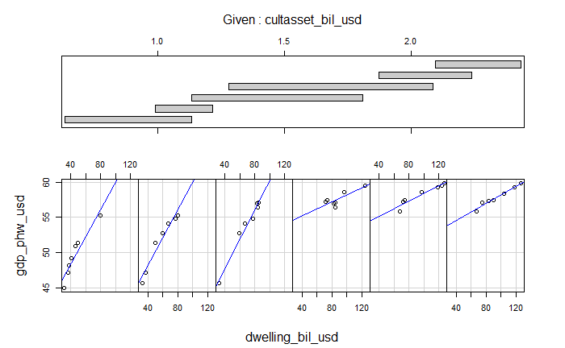

```r
coplot(gdp_phw_usd ~ dwelling_bil_usd | cultasset_bil_usd,
       rows = 1,
       panel = function(x, y, ...){
         points(x, y)
         abline(lm(y ~ x), col = "blue")
       },
       data = prod_uk_trim)
```

Model with interaction term `dwelling_bil_usd:cultasset_bil_usd` included (model_3a)

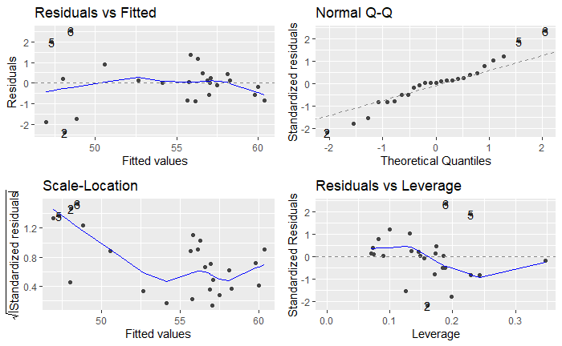

```r
model_3a <- lm(gdp_phw_usd ~ dwelling_bil_usd + cultasset_bil_usd +
                 dwelling_bil_usd:cultasset_bil_usd, data = prod_uk_trim)

autoplot(model_3a) #diagnostics
```

```r
summary(model_3a)
```

```
Call:
lm(formula = gdp_phw_usd ~ dwelling_bil_usd + cultasset_bil_usd +
    dwelling_bil_usd:cultasset_bil_usd, data = prod_uk_trim)

Residuals:
     Min       1Q   Median       3Q      Max
-2.36244 -0.55524  0.05582  0.44002  2.50908

Coefficients:
                                   Estimate Std. Error t value Pr(>|t|)
(Intercept)                        33.15149    2.17231  15.261 7.71e-13 ***
dwelling_bil_usd                    0.27874    0.03529   7.898 1.01e-07 ***
cultasset_bil_usd                   8.22688    1.50798   5.456 2.06e-05 ***
dwelling_bil_usd:cultasset_bil_usd -0.09483    0.01989  -4.768 0.000104 ***
---
Signif. codes:  0 ‘***’ 0.001 ‘**’ 0.01 ‘*’ 0.05 ‘.’ 0.1 ‘ ’ 1

Residual standard error: 1.19 on 21 degrees of freedom
Multiple R-squared:  0.9379,    Adjusted R-squared:  0.929
F-statistic: 105.7 on 3 and 21 DF,  p-value: 7.797e-13
```

Adding the interaction term had a significant impact on the model performance!!!

- Adding a fourth predictor to the model

Calculate residuals

[output not shown]

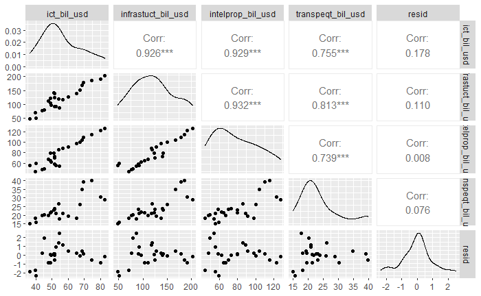

```r
prod_uk_remaining_resid <- prod_uk_trim %>%
  add_residuals(model_3a) %>%
  select(-c(gdp_phw_usd, dwelling_bil_usd, cultasset_bil_usd))


prod_uk_remaining_resid %>%
  ggpairs()
```

It seems that `ict_bil_usd` is a good candidate for a fourth predictor followed by `infrastuct_bil_usd`

Model with `ict_bil_usd` (model_4a)

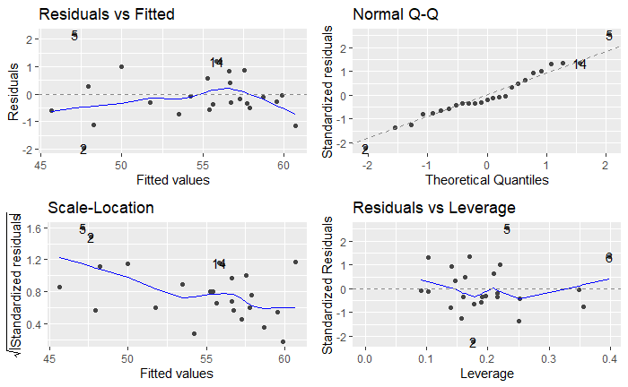

```r
model_4a <- lm(gdp_phw_usd ~ dwelling_bil_usd + cultasset_bil_usd +
                 dwelling_bil_usd:cultasset_bil_usd + ict_bil_usd,
               data = prod_uk_trim)

autoplot(model_4a) #diagnostics
```

```r
summary(model_4a)
```

```
Call:
lm(formula = gdp_phw_usd ~ dwelling_bil_usd + cultasset_bil_usd +
    dwelling_bil_usd:cultasset_bil_usd + ict_bil_usd, data = prod_uk_trim)

Residuals:
    Min      1Q  Median      3Q     Max
-1.9515 -0.5039 -0.1834  0.5616  2.1581

Coefficients:
                                   Estimate Std. Error t value Pr(>|t|)
(Intercept)                        22.78767    3.53879   6.439 2.79e-06 ***
dwelling_bil_usd                    0.31017    0.03029  10.239 2.13e-09 ***
cultasset_bil_usd                  11.48370    1.56319   7.346 4.24e-07 ***
ict_bil_usd                         0.18359    0.05423   3.385  0.00294 **
dwelling_bil_usd:cultasset_bil_usd -0.15193    0.02342  -6.486 2.53e-06 ***
---
Signif. codes:  0 ‘***’ 0.001 ‘**’ 0.01 ‘*’ 0.05 ‘.’ 0.1 ‘ ’ 1

Residual standard error: 0.9718 on 20 degrees of freedom
Multiple R-squared:  0.9605,    Adjusted R-squared:  0.9526
F-statistic: 121.7 on 4 and 20 DF,  p-value: 9.735e-14
```

Model with `infrastuct_bil_usd` (model_4b)

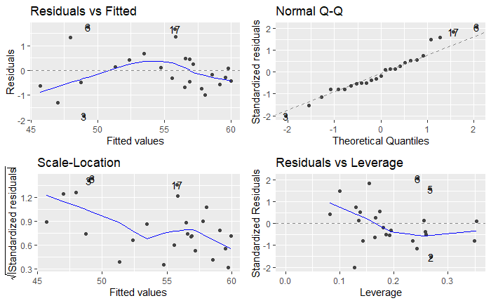

```r
model_4b <- lm(gdp_phw_usd ~ dwelling_bil_usd + cultasset_bil_usd +
                 dwelling_bil_usd:cultasset_bil_usd + infrastuct_bil_usd,
               data = prod_uk_trim)

autoplot(model_4b) #diagnostics
```

```r
summary(model_4b)
```

```
Call:
lm(formula = gdp_phw_usd ~ dwelling_bil_usd + cultasset_bil_usd +
    dwelling_bil_usd:cultasset_bil_usd + infrastuct_bil_usd,
    data = prod_uk_trim)

Residuals:
   Min     1Q Median     3Q    Max
-1.825 -0.549 -0.156  0.467  1.745

Coefficients:
                                   Estimate Std. Error t value Pr(>|t|)
(Intercept)                        29.87813    2.03303  14.696 3.51e-12 ***
dwelling_bil_usd                    0.21181    0.03519   6.019 6.95e-06 ***
cultasset_bil_usd                   9.16173    1.26835   7.223 5.44e-07 ***
infrastuct_bil_usd                  0.08507    0.02542   3.346  0.00321 **
dwelling_bil_usd:cultasset_bil_usd -0.12243    0.01828  -6.696 1.62e-06 ***
---
Signif. codes:  0 ‘***’ 0.001 ‘**’ 0.01 ‘*’ 0.05 ‘.’ 0.1 ‘ ’ 1

Residual standard error: 0.9759 on 20 degrees of freedom
Multiple R-squared:  0.9602,    Adjusted R-squared:  0.9522
F-statistic: 120.6 on 4 and 20 DF,  p-value: 1.058e-13
```

We carry on with model_4a as it is marginally better

- Adding a fifth predictor to the model

Calculate residuals

[output not shown]

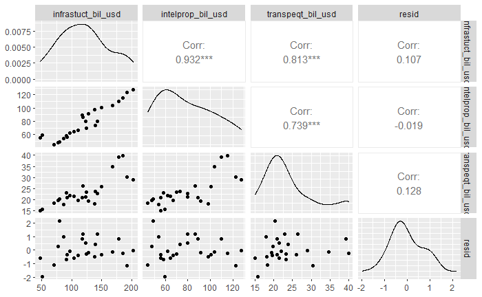

```r
prod_uk_remaining_resid <- prod_uk_trim %>%
  add_residuals(model_4a) %>%
  select(-c(gdp_phw_usd, dwelling_bil_usd, cultasset_bil_usd, ict_bil_usd))


prod_uk_remaining_resid %>%
  ggpairs()
```

It seems that `transpeqt_bil_usd` is a good candidate for a fifth predictor,`ifrastruct_bil_usd` is not so likely

Model with `transpeqt_bil_usd` (model_5a)

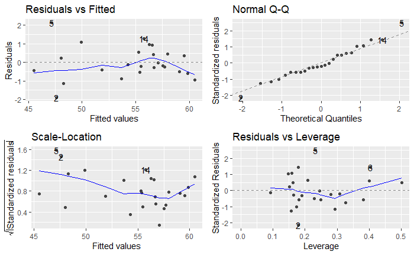

```r
model_5a <- lm(gdp_phw_usd ~ dwelling_bil_usd + cultasset_bil_usd +
                 dwelling_bil_usd:cultasset_bil_usd + ict_bil_usd +
                 transpeqt_bil_usd, data = prod_uk_trim)

autoplot(model_5a) #diagnostics
```

```r
summary(model_5a)
```

```
Call:
lm(formula = gdp_phw_usd ~ dwelling_bil_usd + cultasset_bil_usd +
    dwelling_bil_usd:cultasset_bil_usd + ict_bil_usd + transpeqt_bil_usd,
    data = prod_uk_trim)

Residuals:
    Min      1Q  Median      3Q     Max
-1.8874 -0.4849 -0.1729  0.4566  2.1231

Coefficients:
                                   Estimate Std. Error t value Pr(>|t|)
(Intercept)                        21.41747    3.80712   5.626 2.00e-05 ***
dwelling_bil_usd                    0.31158    0.03036  10.264 3.45e-09 ***
cultasset_bil_usd                  11.97935    1.64407   7.286 6.52e-07 ***
ict_bil_usd                         0.18762    0.05444   3.447   0.0027 **
transpeqt_bil_usd                   0.05108    0.05204   0.982   0.3386
dwelling_bil_usd:cultasset_bil_usd -0.15932    0.02462  -6.470 3.36e-06 ***
---
Signif. codes:  0 ‘***’ 0.001 ‘**’ 0.01 ‘*’ 0.05 ‘.’ 0.1 ‘ ’ 1

Residual standard error: 0.9727 on 19 degrees of freedom
Multiple R-squared:  0.9624,    Adjusted R-squared:  0.9525
F-statistic: 97.36 on 5 and 19 DF,  p-value: 7.264e-13
```

Model with `ifrastruct_bil_usd` (model_5b)

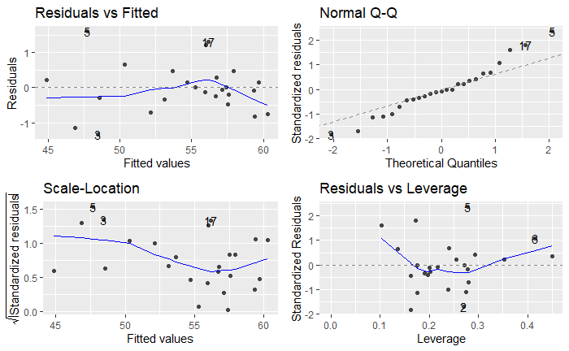

```r
model_5b <- lm(gdp_phw_usd ~ dwelling_bil_usd + cultasset_bil_usd +
                 dwelling_bil_usd:cultasset_bil_usd + ict_bil_usd +
                 infrastuct_bil_usd, data = prod_uk_trim)

autoplot(model_5b) #diagnostics
```

```r
summary(model_5b)
```

```
Call:
lm(formula = gdp_phw_usd ~ dwelling_bil_usd + cultasset_bil_usd +
    dwelling_bil_usd:cultasset_bil_usd + ict_bil_usd + infrastuct_bil_usd,
    data = prod_uk_trim)

Residuals:
     Min       1Q   Median       3Q      Max
-1.32546 -0.32760 -0.05703  0.28775  1.59919

Coefficients:
                                   Estimate Std. Error t value Pr(>|t|)
(Intercept)                        22.00862    2.92465   7.525 4.11e-07 ***
dwelling_bil_usd                    0.24994    0.03112   8.030 1.58e-07 ***
cultasset_bil_usd                  11.65212    1.28858   9.043 2.59e-08 ***
ict_bil_usd                         0.15016    0.04585   3.275  0.00398 **
infrastuct_bil_usd                  0.06928    0.02140   3.237  0.00433 **
dwelling_bil_usd:cultasset_bil_usd -0.16401    0.01965  -8.347 8.88e-08 ***
---
Signif. codes:  0 ‘***’ 0.001 ‘**’ 0.01 ‘*’ 0.05 ‘.’ 0.1 ‘ ’ 1

Residual standard error: 0.8005 on 19 degrees of freedom
Multiple R-squared:  0.9746,    Adjusted R-squared:  0.9679
F-statistic: 145.6 on 5 and 19 DF,  p-value: 1.821e-14
```

We carry on with model_5b as it is better than model_5a

- Adding a sixth predictor to the model

Calculate residuals

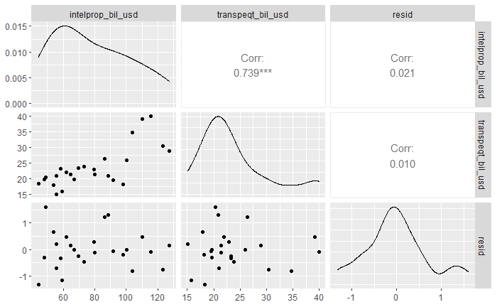

```r
prod_uk_remaining_resid <- prod_uk_trim %>%
  add_residuals(model_5b) %>%
  select(-c(gdp_phw_usd, dwelling_bil_usd, cultasset_bil_usd, ict_bil_usd, infrastuct_bil_usd))


prod_uk_remaining_resid %>%
  ggpairs()
```

Candidates for including in the model in order of importance are: `intelprop_bil_usd` and `transpeqt_bil_usd`

Model with `intelprop_bil_usd` (model_6a)

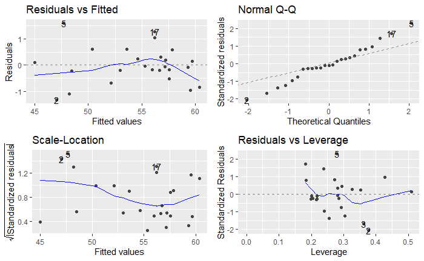

```r
model_6a <- lm(gdp_phw_usd ~ dwelling_bil_usd + cultasset_bil_usd +
                 dwelling_bil_usd:cultasset_bil_usd + ict_bil_usd +
                 infrastuct_bil_usd +intelprop_bil_usd, data = prod_uk_trim)

autoplot(model_6a) #diagnostics
```

```r
summary(model_6a)
```

```
Call:
lm(formula = gdp_phw_usd ~ dwelling_bil_usd + cultasset_bil_usd +
    dwelling_bil_usd:cultasset_bil_usd + ict_bil_usd + infrastuct_bil_usd +
    intelprop_bil_usd, data = prod_uk_trim)

Residuals:
     Min       1Q   Median       3Q      Max
-1.31488 -0.22419 -0.06402  0.29969  1.57998

Coefficients:
                                   Estimate Std. Error t value Pr(>|t|)
(Intercept)                        20.91927    3.45540   6.054 1.01e-05 ***
dwelling_bil_usd                    0.24775    0.03184   7.781 3.63e-07 ***
cultasset_bil_usd                  11.73682    1.31716   8.911 5.11e-08 ***
ict_bil_usd                         0.13991    0.04946   2.829  0.01113 *
infrastuct_bil_usd                  0.07490    0.02357   3.177  0.00522 **
intelprop_bil_usd                   0.02884    0.04660   0.619  0.54380
dwelling_bil_usd:cultasset_bil_usd -0.17385    0.02553  -6.810 2.24e-06 ***
---
Signif. codes:  0 ‘***’ 0.001 ‘**’ 0.01 ‘*’ 0.05 ‘.’ 0.1 ‘ ’ 1

Residual standard error: 0.8138 on 18 degrees of freedom
Multiple R-squared:  0.9751,    Adjusted R-squared:  0.9668
F-statistic: 117.4 on 6 and 18 DF,  p-value: 1.94e-13
```

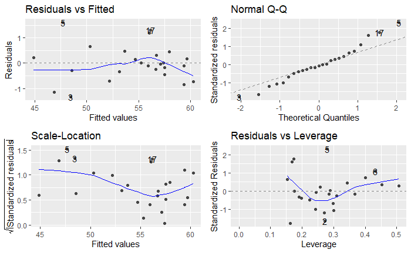

```r
model_6b <- lm(gdp_phw_usd ~ dwelling_bil_usd + cultasset_bil_usd +
                 dwelling_bil_usd:cultasset_bil_usd + ict_bil_usd +
                 infrastuct_bil_usd + transpeqt_bil_usd, data = prod_uk_trim)

autoplot(model_6b) #diagnostics
```

```r
summary(model_6b)
```

```
Call:
lm(formula = gdp_phw_usd ~ dwelling_bil_usd + cultasset_bil_usd +
    dwelling_bil_usd:cultasset_bil_usd + ict_bil_usd + infrastuct_bil_usd +
    transpeqt_bil_usd, data = prod_uk_trim)

Residuals:
     Min       1Q   Median       3Q      Max
-1.32581 -0.34361 -0.04644  0.30212  1.60178

Coefficients:
                                    Estimate Std. Error t value Pr(>|t|)
(Intercept)                        21.917730   3.222721   6.801 2.28e-06 ***
dwelling_bil_usd                    0.250586   0.033038   7.585 5.19e-07 ***
cultasset_bil_usd                  11.686032   1.393346   8.387 1.24e-07 ***
ict_bil_usd                         0.150754   0.047705   3.160  0.00542 **
infrastuct_bil_usd                  0.068651   0.023423   2.931  0.00893 **
transpeqt_bil_usd                   0.003653   0.046871   0.078  0.93874
dwelling_bil_usd:cultasset_bil_usd -0.164433   0.020888  -7.872 3.08e-07 ***
---
Signif. codes:  0 ‘***’ 0.001 ‘**’ 0.01 ‘*’ 0.05 ‘.’ 0.1 ‘ ’ 1

Residual standard error: 0.8223 on 18 degrees of freedom
Multiple R-squared:  0.9746,    Adjusted R-squared:  0.9661
F-statistic:   115 on 6 and 18 DF,  p-value: 2.335e-13
```

Check with ANOVA if it is worth including term `intelprop_bil_usd` (model_6a) in the model

```r
anova(model_5b, model_6a)
```

```
Analysis of Variance Table

Model 1: gdp_phw_usd ~ dwelling_bil_usd + cultasset_bil_usd + dwelling_bil_usd:cultasset_bil_usd +
    ict_bil_usd + infrastuct_bil_usd
Model 2: gdp_phw_usd ~ dwelling_bil_usd + cultasset_bil_usd + dwelling_bil_usd:cultasset_bil_usd +
    ict_bil_usd + infrastuct_bil_usd + intelprop_bil_usd
  Res.Df    RSS Df Sum of Sq      F Pr(>F)
1     19 12.174
2     18 11.921  1   0.25359 0.3829 0.5438
```

ANOVA results don’t justify the addition of `intelprop_bil_usd` so we stay with model_5b

- Adding an interaction term in the model

Let’s see if adding an interaction makes any improvement in our model (model_5b).

Check for including in the model potential interactions between the predictors below + dwelling_bil_usd + cultasset_bil_usd + ict_bil_usd + infrastuct_bil_usd

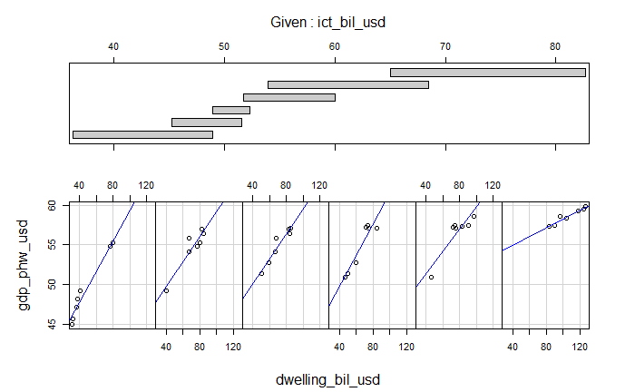

```r
coplot(gdp_phw_usd ~ dwelling_bil_usd | ict_bil_usd,
       rows = 1,
       panel = function(x, y, ...){
         points(x, y)
         abline(lm(y ~ x), col = "blue")
       },
       data = prod_uk_trim)
```

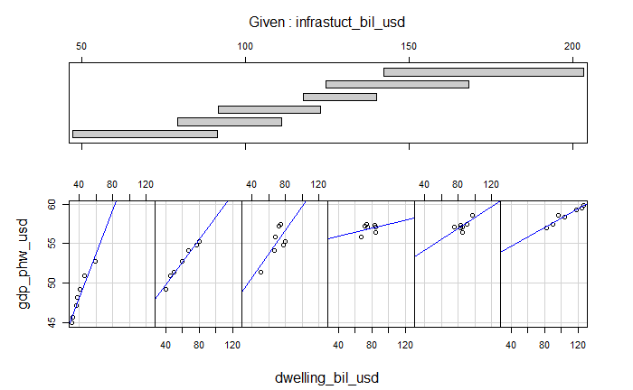

```r
coplot(gdp_phw_usd ~ dwelling_bil_usd | infrastuct_bil_usd,
       rows = 1,
       panel = function(x, y, ...){
         points(x, y)
         abline(lm(y ~ x), col = "blue")
       },
       data = prod_uk_trim)
```

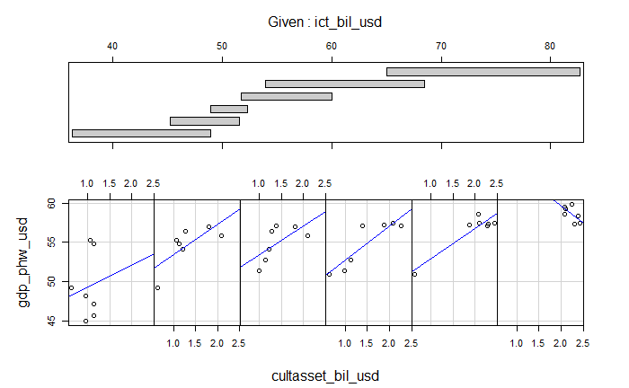

```r
coplot(gdp_phw_usd ~ cultasset_bil_usd | ict_bil_usd,
       rows = 1,
       panel = function(x, y, ...){
         points(x, y)
         abline(lm(y ~ x), col = "blue")
       },
       data = prod_uk_trim)
```

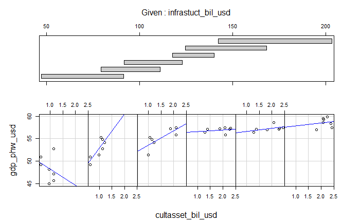

```r
coplot(gdp_phw_usd ~ cultasset_bil_usd | infrastuct_bil_usd,
       rows = 1,
       panel = function(x, y, ...){
         points(x, y)
         abline(lm(y ~ x), col = "blue")
       },
       data = prod_uk_trim)
```

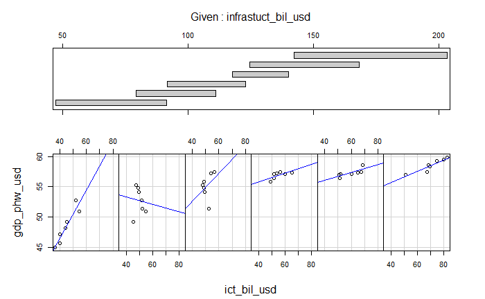

```r
coplot(gdp_phw_usd ~ ict_bil_usd | infrastuct_bil_usd,
       rows = 1,
       panel = function(x, y, ...){
         points(x, y)
         abline(lm(y ~ x), col = "blue")
       },
       data = prod_uk_trim)
```

The best candidate is likely to be: + `cultasset_bil_usd:ict_bil_usd` + `cultasset_bil_usd:infrastuct_bil_usd` + `ict_bil_usd:infrastuct_bil_usd`

Model with `cultasset_bil_usd:ict_bil_usd` (model_6c)

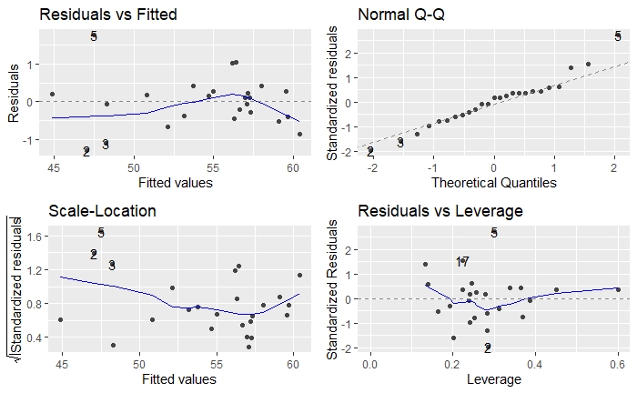

```r
model_6c <- lm(gdp_phw_usd ~ dwelling_bil_usd + cultasset_bil_usd +
                 dwelling_bil_usd:cultasset_bil_usd + ict_bil_usd +
                 infrastuct_bil_usd + cultasset_bil_usd:ict_bil_usd,
               data = prod_uk_trim)

autoplot(model_6c) #diagnostics
```

```r
summary(model_6c)
```

```
Call:
lm(formula = gdp_phw_usd ~ dwelling_bil_usd + cultasset_bil_usd +
    dwelling_bil_usd:cultasset_bil_usd + ict_bil_usd + infrastuct_bil_usd +
    cultasset_bil_usd:ict_bil_usd, data = prod_uk_trim)

Residuals:
    Min      1Q  Median      3Q     Max
-1.2877 -0.3972  0.1052  0.2687  1.7671

Coefficients:
                                   Estimate Std. Error t value Pr(>|t|)
(Intercept)                        17.95617    4.03189   4.454 0.000307 ***
dwelling_bil_usd                    0.20373    0.04447   4.581 0.000232 ***
cultasset_bil_usd                  14.77889    2.53387   5.833 1.59e-05 ***
ict_bil_usd                         0.31745    0.12594   2.521 0.021375 *
infrastuct_bil_usd                  0.04725    0.02598   1.818 0.085688 .
dwelling_bil_usd:cultasset_bil_usd -0.10866    0.04342  -2.503 0.022186 *
cultasset_bil_usd:ict_bil_usd      -0.12045    0.08479  -1.421 0.172526
---
Signif. codes:  0 ‘***’ 0.001 ‘**’ 0.01 ‘*’ 0.05 ‘.’ 0.1 ‘ ’ 1

Residual standard error: 0.7798 on 18 degrees of freedom
Multiple R-squared:  0.9771,    Adjusted R-squared:  0.9695
F-statistic: 128.2 on 6 and 18 DF,  p-value: 9.044e-14
```

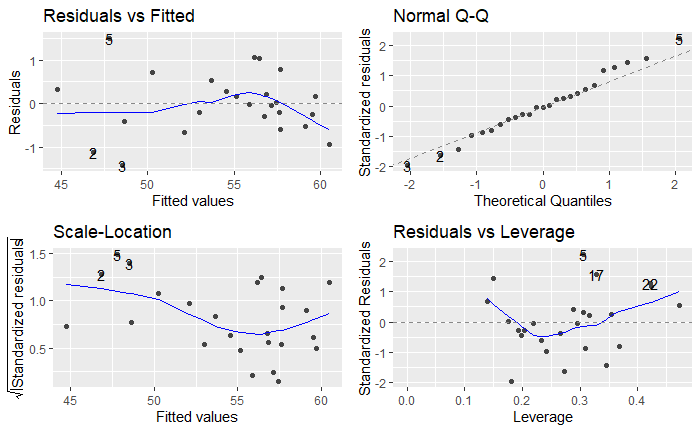

```r
model_6d <- lm(gdp_phw_usd ~ dwelling_bil_usd + cultasset_bil_usd +
                 dwelling_bil_usd:cultasset_bil_usd + ict_bil_usd +
                 infrastuct_bil_usd + cultasset_bil_usd:infrastuct_bil_usd,
               data = prod_uk_trim)

autoplot(model_6d) #diagnostics
```

```r
summary(model_6d)
```

```
Call:
lm(formula = gdp_phw_usd ~ dwelling_bil_usd + cultasset_bil_usd +
    dwelling_bil_usd:cultasset_bil_usd + ict_bil_usd + infrastuct_bil_usd +
    cultasset_bil_usd:infrastuct_bil_usd, data = prod_uk_trim)

Residuals:
     Min       1Q   Median       3Q      Max
-1.41717 -0.42421 -0.03119  0.31268  1.48458

Coefficients:
                                     Estimate Std. Error t value Pr(>|t|)
(Intercept)                          21.79380    2.95492   7.375 7.65e-07 ***
dwelling_bil_usd                      0.16842    0.09947   1.693   0.1077
cultasset_bil_usd                    12.24528    1.46794   8.342 1.34e-07 ***
ict_bil_usd                           0.13398    0.04981   2.690   0.0150 *
infrastuct_bil_usd                    0.12539    0.06846   1.832   0.0836 .
dwelling_bil_usd:cultasset_bil_usd   -0.10034    0.07635  -1.314   0.2053
cultasset_bil_usd:infrastuct_bil_usd -0.04165    0.04823  -0.863   0.3992
---
Signif. codes:  0 ‘***’ 0.001 ‘**’ 0.01 ‘*’ 0.05 ‘.’ 0.1 ‘ ’ 1

Residual standard error: 0.8059 on 18 degrees of freedom
Multiple R-squared:  0.9756,    Adjusted R-squared:  0.9674
F-statistic: 119.8 on 6 and 18 DF,  p-value: 1.629e-13
```

Model with `ict_bil_usd:infrastuct_bil_usd` (model_6e)

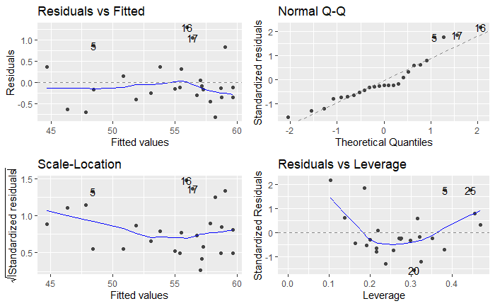

```r
model_6e <- lm(gdp_phw_usd ~ dwelling_bil_usd + cultasset_bil_usd +
                 dwelling_bil_usd:cultasset_bil_usd + ict_bil_usd +
                 infrastuct_bil_usd + ict_bil_usd:infrastuct_bil_usd,
               data = prod_uk_trim)

autoplot(model_6e) #diagnostics
```

```r
summary(model_6e)
```

```
Call:
lm(formula = gdp_phw_usd ~ dwelling_bil_usd + cultasset_bil_usd +
    dwelling_bil_usd:cultasset_bil_usd + ict_bil_usd + infrastuct_bil_usd +
    ict_bil_usd:infrastuct_bil_usd, data = prod_uk_trim)

Residuals:
    Min      1Q  Median      3Q     Max
-0.8183 -0.3594 -0.1323  0.3106  1.2939

Coefficients:
                                     Estimate Std. Error t value Pr(>|t|)
(Intercept)                        22.2934433  2.2987019   9.698 1.43e-08 ***
dwelling_bil_usd                    0.1702616  0.0330748   5.148 6.75e-05 ***
cultasset_bil_usd                   4.6588299  2.2016520   2.116  0.04854 *
ict_bil_usd                         0.3148543  0.0584555   5.386 4.06e-05 ***
infrastuct_bil_usd                  0.1279905  0.0234945   5.448 3.56e-05 ***
dwelling_bil_usd:cultasset_bil_usd -0.0550735  0.0341457  -1.613  0.12416
ict_bil_usd:infrastuct_bil_usd     -0.0018881  0.0005279  -3.577  0.00216 **
---
Signif. codes:  0 ‘***’ 0.001 ‘**’ 0.01 ‘*’ 0.05 ‘.’ 0.1 ‘ ’ 1

Residual standard error: 0.6288 on 18 degrees of freedom
Multiple R-squared:  0.9851,    Adjusted R-squared:  0.9802
F-statistic: 198.8 on 6 and 18 DF,  p-value: 1.903e-15
```

Check with ANOVA if the interaction terms are worth including in the model

```r
anova(model_5b, model_6c)
```

```
Analysis of Variance Table

Model 1: gdp_phw_usd ~ dwelling_bil_usd + cultasset_bil_usd + dwelling_bil_usd:cultasset_bil_usd +
    ict_bil_usd + infrastuct_bil_usd
Model 2: gdp_phw_usd ~ dwelling_bil_usd + cultasset_bil_usd + dwelling_bil_usd:cultasset_bil_usd +
    ict_bil_usd + infrastuct_bil_usd + cultasset_bil_usd:ict_bil_usd
  Res.Df    RSS Df Sum of Sq      F Pr(>F)
1     19 12.174
2     18 10.947  1    1.2273 2.0181 0.1725
```

```r
anova(model_5b, model_6d)
```

```
Analysis of Variance Table

Model 1: gdp_phw_usd ~ dwelling_bil_usd + cultasset_bil_usd + dwelling_bil_usd:cultasset_bil_usd +
    ict_bil_usd + infrastuct_bil_usd
Model 2: gdp_phw_usd ~ dwelling_bil_usd + cultasset_bil_usd + dwelling_bil_usd:cultasset_bil_usd +
    ict_bil_usd + infrastuct_bil_usd + cultasset_bil_usd:infrastuct_bil_usd
  Res.Df    RSS Df Sum of Sq      F Pr(>F)
1     19 12.174
2     18 11.690  1   0.48421 0.7456 0.3992
```

```r
anova(model_5b, model_6e)
```

```
Analysis of Variance Table

Model 1: gdp_phw_usd ~ dwelling_bil_usd + cultasset_bil_usd + dwelling_bil_usd:cultasset_bil_usd +
    ict_bil_usd + infrastuct_bil_usd
Model 2: gdp_phw_usd ~ dwelling_bil_usd + cultasset_bil_usd + dwelling_bil_usd:cultasset_bil_usd +
    ict_bil_usd + infrastuct_bil_usd + ict_bil_usd:infrastuct_bil_usd
  Res.Df     RSS Df Sum of Sq      F   Pr(>F)
1     19 12.1742
2     18  7.1163  1    5.0579 12.793 0.002156 **
---
Signif. codes:  0 ‘***’ 0.001 ‘**’ 0.01 ‘*’ 0.05 ‘.’ 0.1 ‘ ’ 1
```

The model_6e is the best calculated so far

- Check if it is worth adding a seventh predictor to the model

Calculate residuals

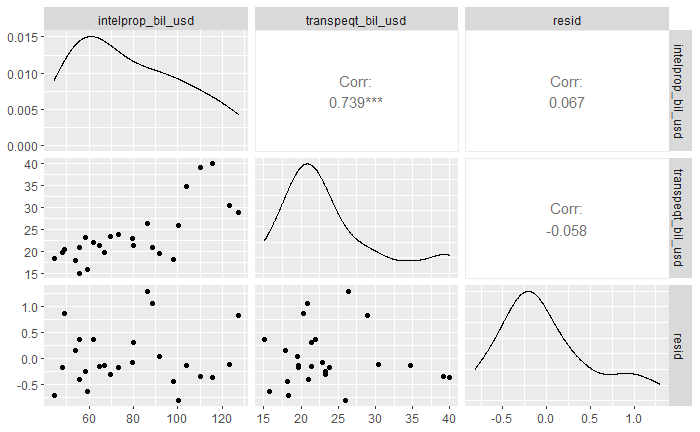

```r
prod_uk_remaining_resid <- prod_uk_trim %>%
  add_residuals(model_6e) %>%
  select(-c(gdp_phw_usd, dwelling_bil_usd, cultasset_bil_usd, ict_bil_usd, infrastuct_bil_usd))


prod_uk_remaining_resid %>%
  ggpairs()
```

The residuals have very low correlation. The search can stop at this point.

Checking of relative importance of model terms

```r
library(relaimpo)
calc.relimp(model_6e, type = "lmg", rela = TRUE)
```

```
Response variable: gdp_phw_usd
Total response variance: 19.94055
Analysis based on 25 observations

6 Regressors:
dwelling_bil_usd cultasset_bil_usd ict_bil_usd infrastuct_bil_usd dwelling_bil_usd:cultasset_bil_usd ict_bil_usd:infrastuct_bil_usd
Proportion of variance explained by model: 98.51%
Metrics are normalized to sum to 100% (rela=TRUE).

Relative importance metrics:

                                          lmg
dwelling_bil_usd                   0.28006561
cultasset_bil_usd                  0.17103660
ict_bil_usd                        0.18168913
infrastuct_bil_usd                 0.26439755
dwelling_bil_usd:cultasset_bil_usd 0.04601975
ict_bil_usd:infrastuct_bil_usd     0.05679135

Average coefficients for different model sizes:

                                          1X        2Xs          3Xs          4Xs          5Xs          6Xs
dwelling_bil_usd                   0.1488264 0.12565770  0.156617494  0.186659226  0.189237461  0.170261594
cultasset_bil_usd                  5.9056692 1.94681909  3.231842255  5.742954577  6.404859453  4.658829943
ict_bil_usd                        0.2916131 0.01812557  0.021443271  0.201283784  0.257147057  0.314854263
infrastuct_bil_usd                 0.0956436 0.08065241  0.105622082  0.131069641  0.109279315  0.127990545
dwelling_bil_usd:cultasset_bil_usd       NaN        NaN -0.094826003 -0.137179673 -0.164014559 -0.055073516
ict_bil_usd:infrastuct_bil_usd           NaN        NaN -0.002582157 -0.002626458 -0.002647584 -0.001888123
```

**Automated modelling**

```r
library(glmulti)
glmulti_fit <- glmulti(
  gdp_phw_usd ~ .,
  data = prod_uk_trim,
  level = 2, # 2 = include pairwise interactions, 1 = main effects only (main effect = no pairwise interactions)
  minsize = 0, # no min size of model
  maxsize = 6, # -1 = no max size of model
  marginality = TRUE, # marginality here means the same as 'strongly hierarchical' interactions, i.e. include pairwise interactions only if both predictors present in the model as main effects.
  method = "g", # the problem is too large for exhaustive search, so search using a genetic algorithm
  crit = bic, # criteria for model selection is BIC value (lower is better)
  plotty = FALSE, # don't plot models as function runs
  report = TRUE, # do produce reports as function runs
  confsetsize = 100, # return best 100 solutions
  fitfunction = lm # fit using the `lm` function
)
```

```
Initialization...
TASK: Genetic algorithm in the candidate set.
Initialization...
Algorithm started...

After 10 generations:
Best model: gdp_phw_usd~1+cultasset_bil_usd+infrastuct_bil_usd+intelprop_bil_usd+dwelling_bil_usd+dwelling_bil_usd:infrastuct_bil_usd
Crit= 56.204684161689
Mean crit= 86.8527517758042
Change in best IC: -9943.79531583831 / Change in mean IC: -9913.1472482242

After 20 generations:
Best model: gdp_phw_usd~1+cultasset_bil_usd+infrastuct_bil_usd+intelprop_bil_usd+dwelling_bil_usd+dwelling_bil_usd:cultasset_bil_usd+dwelling_bil_usd:infrastuct_bil_usd
Crit= 55.6768031771476
Mean crit= 79.7952301305639
Change in best IC: -0.527880984541412 / Change in mean IC: -7.05752164524029

After 30 generations:
Best model: gdp_phw_usd~1+cultasset_bil_usd+infrastuct_bil_usd+intelprop_bil_usd+dwelling_bil_usd+infrastuct_bil_usd:cultasset_bil_usd+dwelling_bil_usd:infrastuct_bil_usd
Crit= 49.3307496150759
Mean crit= 76.5521037820245
Change in best IC: -6.34605356207172 / Change in mean IC: -3.24312634853942

After 40 generations:
Best model: gdp_phw_usd~1+cultasset_bil_usd+infrastuct_bil_usd+intelprop_bil_usd+dwelling_bil_usd+infrastuct_bil_usd:cultasset_bil_usd+dwelling_bil_usd:infrastuct_bil_usd
Crit= 49.3307496150759
Mean crit= 73.8173813749233
Change in best IC: 0 / Change in mean IC: -2.73472240710122

After 50 generations:
Best model: gdp_phw_usd~1+cultasset_bil_usd+infrastuct_bil_usd+intelprop_bil_usd+dwelling_bil_usd+infrastuct_bil_usd:cultasset_bil_usd+dwelling_bil_usd:infrastuct_bil_usd
Crit= 49.3307496150759
Mean crit= 72.9624448968507
Change in best IC: 0 / Change in mean IC: -0.85493647807256

After 60 generations:
Best model: gdp_phw_usd~1+cultasset_bil_usd+infrastuct_bil_usd+intelprop_bil_usd+dwelling_bil_usd+infrastuct_bil_usd:cultasset_bil_usd+dwelling_bil_usd:infrastuct_bil_usd
Crit= 49.3307496150759
Mean crit= 71.4866780971691
Change in best IC: 0 / Change in mean IC: -1.47576679968159
```

[output cut: 209 more lines]

[output not shown]

Summary of glmulti results

```r
summary(glmulti_fit)
```

```
$name
[1] "glmulti.analysis"

$method
[1] "g"

$fitting
[1] "lm"

$crit
[1] "bic"

$level
[1] 2

$marginality
[1] TRUE

$confsetsize
[1] 100

$bestic
[1] 49.33075

$icvalues
  [1] 49.33075 55.67680 56.20468 56.55964 57.02945 57.10769 58.16478 58.35922 58.37766 58.58979 58.70080 58.76433 58.82784
 [14] 59.35794 59.41643 59.73672 59.80486 59.91400 60.01813 60.23926 60.84240 60.87584 61.21856 61.52268 61.67393 61.69714
 [27] 61.97470 62.19404 62.52478 62.58987 62.76328 62.77122 62.83302 62.92747 63.00538 63.06098 63.18221 63.26074 63.27490
 [40] 63.30843 63.51447 63.55029 63.61374 63.80878 63.95171 64.49865 64.79650 65.00164 65.15106 65.26918 65.28582 65.41296
 [53] 65.44166 65.55156 65.62047 65.78757 65.78882 65.91789 66.13587 66.17188 66.17749 66.55359 66.79039 67.14101 67.42008
 [66] 67.45456 67.51034 67.68118 67.76719 67.96365 67.99490 68.00286 68.02477 68.32821 68.34297 68.37827 68.40555 68.46458
 [79] 68.54663 68.63295 68.74188 68.91153 68.92463 68.94909 68.99457 69.45364 69.52918 69.65318 69.69883 69.89848 69.96745
 [92] 70.05665 70.06261 70.21565 70.33763 70.34419 70.35606 70.42668 70.48991 70.61996

$bestmodel
[1] "gdp_phw_usd ~ 1 + cultasset_bil_usd + infrastuct_bil_usd + intelprop_bil_usd + "
[2] "    dwelling_bil_usd + infrastuct_bil_usd:cultasset_bil_usd + "
[3] "    dwelling_bil_usd:infrastuct_bil_usd"

$modelweights
  [1] 7.723429e-01 3.234314e-02 2.484015e-02 2.080062e-02 1.644590e-02 1.581503e-02 9.322343e-03 8.458686e-03 8.381037e-03
 [10] 7.537642e-03 7.130652e-03 6.907700e-03 6.691819e-03 5.133737e-03 4.985784e-03 4.247986e-03 4.105694e-03 3.887640e-03
 [19] 3.690415e-03 3.304123e-03 2.443924e-03 2.403403e-03 2.024903e-03 1.739267e-03 1.612588e-03 1.593981e-03 1.387429e-03
 [28] 1.243318e-03 1.053809e-03 1.020067e-03 9.353475e-04 9.316439e-04 9.032963e-04 8.616261e-04 8.287094e-04 8.059894e-04
 [37] 7.585839e-04 7.293767e-04 7.242297e-04 7.121893e-04 6.424736e-04 6.310690e-04 6.113611e-04 5.545559e-04 5.163074e-04
 [46] 3.927734e-04 3.384276e-04 3.054355e-04 2.834474e-04 2.671923e-04 2.649786e-04 2.486584e-04 2.451149e-04 2.320098e-04
 [55] 2.241518e-04 2.061849e-04 2.060560e-04 1.931783e-04 1.732307e-04 1.701394e-04 1.696633e-04 1.405783e-04 1.248814e-04
 [64] 1.048000e-04 9.115097e-05 8.959293e-05 8.712902e-05 7.999536e-05 7.662804e-05 6.945872e-05 6.838199e-05 6.811029e-05
 [73] 6.736840e-05 5.788464e-05 5.745925e-05 5.645389e-05 5.568894e-05 5.406944e-05 5.189617e-05 4.970403e-05 4.706929e-05
 [82] 4.324112e-05 4.295887e-05 4.243676e-05 4.148261e-05 3.297468e-05 3.175245e-05 2.984348e-05 2.917011e-05 2.639877e-05
 [91] 2.550390e-05 2.439141e-05 2.431890e-05 2.252746e-05 2.119449e-05 2.112514e-05 2.100009e-05 2.027153e-05 1.964067e-05
[100] 1.840416e-05

$generations
[1] 430

$elapsed
[1] 0.02042842

$includeobjects
[1] TRUE
```

```r
# here is the best model (lowest BIC) from the glmulti run above
glmulti_fit@objects[1]
```

```
[[1]]

Call:
fitfunc(formula = as.formula(x), data = data)

Coefficients:
                         (Intercept)                     cultasset_bil_usd                    infrastuct_bil_usd
                           25.370831                              2.671541                              0.189267
                   intelprop_bil_usd                      dwelling_bil_usd  cultasset_bil_usd:infrastuct_bil_usd
                            0.112780                              0.173074                             -0.036716
 infrastuct_bil_usd:dwelling_bil_usd
                           -0.001181
```

```r
# if you want to see the other models
weightable(glmulti_fit)
```

| model | bic | weights |
| --- | --- | --- |
| gdp_phw_usd ~ 1 + cultasset_bil_usd + infrastuct_bil_usd + intelprop_bil_usd + dwelling_bil_usd + infrastuct_bil_usd:cultasset_bil_usd + dwelling_bil_usd:infrastuct_bil_usd | 49.33075 | 7.723429e-01 |
| gdp_phw_usd ~ 1 + cultasset_bil_usd + infrastuct_bil_usd + intelprop_bil_usd + dwelling_bil_usd + dwelling_bil_usd:cultasset_bil_usd + dwelling_bil_usd:infrastuct_bil_usd | 55.67680 | 3.234314e-02 |
| gdp_phw_usd ~ 1 + cultasset_bil_usd + infrastuct_bil_usd + intelprop_bil_usd + dwelling_bil_usd + dwelling_bil_usd:infrastuct_bil_usd | 56.20468 | 2.484015e-02 |
| gdp_phw_usd ~ 1 + cultasset_bil_usd + infrastuct_bil_usd + intelprop_bil_usd + dwelling_bil_usd + intelprop_bil_usd:cultasset_bil_usd + dwelling_bil_usd:infrastuct_bil_usd | 56.55964 | 2.080062e-02 |
| gdp_phw_usd ~ 1 + infrastuct_bil_usd + intelprop_bil_usd + dwelling_bil_usd + dwelling_bil_usd:infrastuct_bil_usd | 57.02945 | 1.644590e-02 |
| gdp_phw_usd ~ 1 + infrastuct_bil_usd + intelprop_bil_usd + transpeqt_bil_usd + dwelling_bil_usd + transpeqt_bil_usd:infrastuct_bil_usd + dwelling_bil_usd:infrastuct_bil_usd | 57.10769 | 1.581503e-02 |
| gdp_phw_usd ~ 1 + cultasset_bil_usd + infrastuct_bil_usd + intelprop_bil_usd + dwelling_bil_usd + dwelling_bil_usd:infrastuct_bil_usd + dwelling_bil_usd:intelprop_bil_usd | 58.16478 | 9.322343e-03 |
| gdp_phw_usd ~ 1 + infrastuct_bil_usd + intelprop_bil_usd + dwelling_bil_usd + intelprop_bil_usd:infrastuct_bil_usd + dwelling_bil_usd:infrastuct_bil_usd + dwelling_bil_usd:intelprop_bil_usd | 58.35922 | 8.458686e-03 |
| gdp_phw_usd ~ 1 + ict_bil_usd + cultasset_bil_usd + infrastuct_bil_usd + dwelling_bil_usd + cultasset_bil_usd:ict_bil_usd + dwelling_bil_usd:infrastuct_bil_usd | 58.37766 | 8.381037e-03 |
| gdp_phw_usd ~ 1 + ict_bil_usd + intelprop_bil_usd + transpeqt_bil_usd + dwelling_bil_usd + transpeqt_bil_usd:ict_bil_usd + dwelling_bil_usd:ict_bil_usd | 58.58979 | 7.537642e-03 |

[output cut: 90 more lines]

```r
# View summary of the best model (lowest BIC) from the glmulti run above
mod_auto1 <- lm(gdp_phw_usd ~ 1 + cultasset_bil_usd + infrastuct_bil_usd +
                 intelprop_bil_usd + dwelling_bil_usd +
                 infrastuct_bil_usd:cultasset_bil_usd +
                 dwelling_bil_usd:infrastuct_bil_usd,
                   data = prod_uk_trim)

summary(mod_auto1)
```

```
Call:
lm(formula = gdp_phw_usd ~ 1 + cultasset_bil_usd + infrastuct_bil_usd +
    intelprop_bil_usd + dwelling_bil_usd + infrastuct_bil_usd:cultasset_bil_usd +
    dwelling_bil_usd:infrastuct_bil_usd, data = prod_uk_trim)

Residuals:
     Min       1Q   Median       3Q      Max
-0.59966 -0.29484 -0.05087  0.21457  0.85219

Coefficients:
                                       Estimate Std. Error t value Pr(>|t|)
(Intercept)                          25.3708305  1.7350410  14.623 1.97e-11 ***
cultasset_bil_usd                     2.6715409  1.4146624   1.888 0.075189 .
infrastuct_bil_usd                    0.1892674  0.0208051   9.097 3.75e-08 ***
intelprop_bil_usd                     0.1127803  0.0241826   4.664 0.000193 ***
dwelling_bil_usd                      0.1730740  0.0281927   6.139 8.49e-06 ***
cultasset_bil_usd:infrastuct_bil_usd -0.0367162  0.0122710  -2.992 0.007818 **
infrastuct_bil_usd:dwelling_bil_usd  -0.0011812  0.0001587  -7.441 6.77e-07 ***
---
Signif. codes:  0 ‘***’ 0.001 ‘**’ 0.01 ‘*’ 0.05 ‘.’ 0.1 ‘ ’ 1

Residual standard error: 0.457 on 18 degrees of freedom
Multiple R-squared:  0.9921,    Adjusted R-squared:  0.9895
F-statistic: 378.9 on 6 and 18 DF,  p-value: < 2.2e-16
```

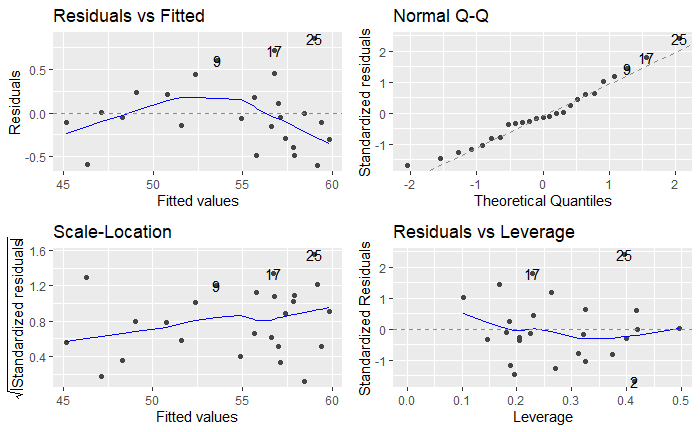

```r
# let's see diagnostic plots
autoplot(mod_auto1)
```

The diagnostic plots don’t look that great, and the `cultasset_bil_usd` coefficient is not statistically significant

Let’s check what the other models calculated by the gmulti algorithm are like

```r
# View summary of the best model (lowest BIC) from the glmulti run above
mod_auto2 <- lm(gdp_phw_usd ~ 1 + infrastuct_bil_usd + intelprop_bil_usd +
                dwelling_bil_usd + dwelling_bil_usd:infrastuct_bil_usd,
                   data = prod_uk_trim)

summary(mod_auto2)
```

```
Call:
lm(formula = gdp_phw_usd ~ 1 + infrastuct_bil_usd + intelprop_bil_usd +
    dwelling_bil_usd + dwelling_bil_usd:infrastuct_bil_usd, data = prod_uk_trim)

Residuals:
     Min       1Q   Median       3Q      Max
-1.14684 -0.35696 -0.01917  0.25889  1.02190

Coefficients:
                                      Estimate Std. Error t value Pr(>|t|)
(Intercept)                          3.108e+01  9.962e-01  31.197  < 2e-16 ***
infrastuct_bil_usd                   1.261e-01  1.452e-02   8.685 3.20e-08 ***
intelprop_bil_usd                    4.979e-02  1.420e-02   3.506  0.00222 **
dwelling_bil_usd                     2.404e-01  2.126e-02  11.306 3.86e-10 ***
infrastuct_bil_usd:dwelling_bil_usd -1.338e-03  9.823e-05 -13.626 1.40e-11 ***
---
Signif. codes:  0 ‘***’ 0.001 ‘**’ 0.01 ‘*’ 0.05 ‘.’ 0.1 ‘ ’ 1

Residual standard error: 0.5752 on 20 degrees of freedom
Multiple R-squared:  0.9862,    Adjusted R-squared:  0.9834
F-statistic: 356.6 on 4 and 20 DF,  p-value: < 2.2e-16
```

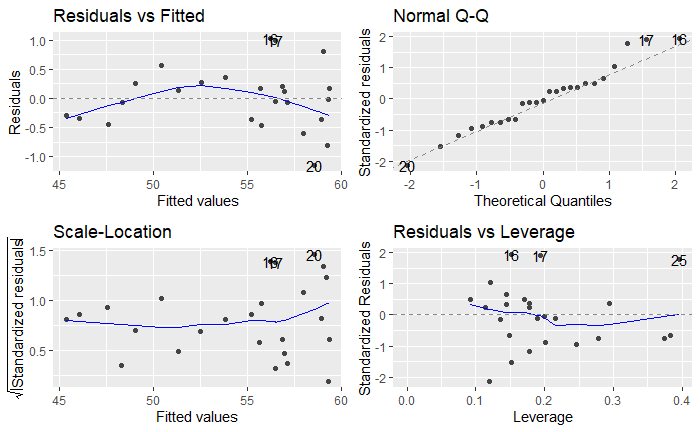

```r
# let's see diagnostic plots
autoplot(mod_auto2)
```

```r
# View summary of the best model (lowest BIC) from the glmulti run above
mod_auto3 <- lm(gdp_phw_usd ~ 1 + ict_bil_usd + cultasset_bil_usd +
                  infrastuct_bil_usd + dwelling_bil_usd +
                  cultasset_bil_usd:ict_bil_usd + dwelling_bil_usd:infrastuct_bil_usd,
                   data = prod_uk_trim)

summary(mod_auto3)
```

```
Call:
lm(formula = gdp_phw_usd ~ 1 + ict_bil_usd + cultasset_bil_usd +
    infrastuct_bil_usd + dwelling_bil_usd + cultasset_bil_usd:ict_bil_usd +
    dwelling_bil_usd:infrastuct_bil_usd, data = prod_uk_trim)

Residuals:
    Min      1Q  Median      3Q     Max
-0.6595 -0.2979 -0.1428  0.1646  1.0839

Coefficients:
                                      Estimate Std. Error t value Pr(>|t|)
(Intercept)                         22.9729453  3.0621277   7.502 6.04e-07 ***
ict_bil_usd                          0.2673784  0.0782419   3.417 0.003071 **
cultasset_bil_usd                    7.7921623  2.3965281   3.251 0.004431 **
infrastuct_bil_usd                   0.0803376  0.0194790   4.124 0.000637 ***
dwelling_bil_usd                     0.2066653  0.0245778   8.409 1.20e-07 ***
ict_bil_usd:cultasset_bil_usd       -0.1263855  0.0421949  -2.995 0.007765 **
infrastuct_bil_usd:dwelling_bil_usd -0.0008769  0.0001570  -5.586 2.66e-05 ***
---
Signif. codes:  0 ‘***’ 0.001 ‘**’ 0.01 ‘*’ 0.05 ‘.’ 0.1 ‘ ’ 1

Residual standard error: 0.5476 on 18 degrees of freedom
Multiple R-squared:  0.9887,    Adjusted R-squared:  0.985
F-statistic:   263 on 6 and 18 DF,  p-value: < 2.2e-16
```

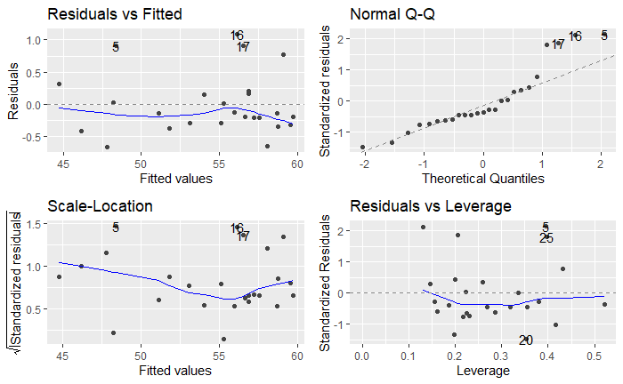

```r
# let's see diagnostic plots
autoplot(mod_auto3)
```

The diagnostic plots don’t look that great, although all predictor coefficients are statistically significant

model_auto2 is a good trade-off between accuracy and model parsimony

```r
calc.relimp(mod_auto2, type = "lmg", rela = TRUE)
```

```
Response variable: gdp_phw_usd
Total response variance: 19.94055
Analysis based on 25 observations

4 Regressors:
infrastuct_bil_usd intelprop_bil_usd dwelling_bil_usd infrastuct_bil_usd:dwelling_bil_usd
Proportion of variance explained by model: 98.62%
Metrics are normalized to sum to 100% (rela=TRUE).

Relative importance metrics:

                                          lmg
infrastuct_bil_usd                  0.3392090
intelprop_bil_usd                   0.1823124
dwelling_bil_usd                    0.3499682
infrastuct_bil_usd:dwelling_bil_usd 0.1285103

Average coefficients for different model sizes:

                                           1X          2Xs          3Xs          4Xs
infrastuct_bil_usd                  0.0956436  0.070723344  0.092790846  0.126098716
intelprop_bil_usd                   0.1522055 -0.008596465 -0.022328081  0.049785353
dwelling_bil_usd                    0.1488264  0.121347416  0.163875966  0.240369357
infrastuct_bil_usd:dwelling_bil_usd       NaN          NaN -0.001210134 -0.001338482
```

**K-fold cross validation**

Cross validation of manually selected model

```r
library(caret)
set.seed(765977)
# set up options for train function below
cv_10_fold <- trainControl(method = "cv", # cross-validation
                           number = 10, # 10-fold
                           savePredictions = TRUE) # save all predictions

model_6e_kfold <- train(gdp_phw_usd ~ dwelling_bil_usd + cultasset_bil_usd +
                          dwelling_bil_usd:cultasset_bil_usd + ict_bil_usd +
                          infrastuct_bil_usd + ict_bil_usd:infrastuct_bil_usd,
                        data = prod_uk_trim,
                        trControl = cv_10_fold, # use options defined above
                        method = 'lm')
```

```r
model_6e_kfold$resample
```

| RMSE | Rsquared | MAE | Resample |
| --- | --- | --- | --- |
| 0.5675803 | 1.0000000 | 0.5486926 | Fold01 |
| 0.4015195 | 0.9908319 | 0.3457269 | Fold02 |
| 0.6119593 | 0.9982908 | 0.5078377 | Fold03 |
| 0.8276917 | 0.9974469 | 0.6447705 | Fold04 |
| 0.6489700 | 1.0000000 | 0.5664462 | Fold05 |
| 0.2356834 | 1.0000000 | 0.2270627 | Fold06 |
| 0.8345160 | 0.8712413 | 0.5920885 | Fold07 |
| 0.3873999 | 0.9972799 | 0.3372480 | Fold08 |
| 0.9606778 | 1.0000000 | 0.8801144 | Fold09 |
| 1.3761534 | 1.0000000 | 1.3670540 | Fold10 |

```r
tibble(
  model = "manually selected model_6e",
  RMSE = mean(model_6e_kfold$resample$RMSE),
  Rsquared = mean(model_6e_kfold$resample$Rsquared)
)
```

| model | RMSE | Rsquared |
| --- | --- | --- |
| manually selected model_6e | 0.6852151 | 0.9855091 |

Cross validation of automatically selected model following some manipulation (mod_auto2)

```r
model_reduced_kfold <- train(gdp_phw_usd ~ 1 + infrastuct_bil_usd +
                               intelprop_bil_usd + dwelling_bil_usd +
                               dwelling_bil_usd:infrastuct_bil_usd,
                             data = prod_uk_trim,
                             trControl = cv_10_fold, # use options defined above
                             method = 'lm')
```

```r
model_reduced_kfold$resample
```

| RMSE | Rsquared | MAE | Resample |
| --- | --- | --- | --- |
| 0.3185902 | 0.9921928 | 0.3080170 | Fold01 |
| 1.0811909 | 0.9998842 | 1.0801300 | Fold02 |
| 0.3979386 | 1.0000000 | 0.2913302 | Fold03 |
| 0.1841823 | 0.9999848 | 0.1448760 | Fold04 |
| 0.9184216 | 1.0000000 | 0.6763375 | Fold05 |
| 0.4662645 | 1.0000000 | 0.3964260 | Fold06 |
| 0.5842674 | 0.9994682 | 0.4730789 | Fold07 |
| 0.7637792 | 0.4585271 | 0.7170698 | Fold08 |
| 0.8606188 | 1.0000000 | 0.6825294 | Fold09 |
| 0.3594567 | 1.0000000 | 0.3505547 | Fold10 |

```r
tibble(
  model = "automatically selected model, then reduced",
  RMSE = mean(model_reduced_kfold$resample$RMSE),
  Rsquared = mean(model_reduced_kfold$resample$Rsquared)
)
```

| model | RMSE | Rsquared |
| --- | --- | --- |
| automatically selected model, then reduced | 0.593471 | 0.9450057 |